# chapter4.Rmd

# Standardization of the dataset and categorization of variables

```r
boston_scaled <- as.data.frame(scale(Boston))
summary(boston_scaled)
```

```
##       crim                 zn               indus
##  Min.   :-0.419367   Min.   :-0.48724   Min.   :-1.5563
##  1st Qu.:-0.410563   1st Qu.:-0.48724   1st Qu.:-0.8668
##  Median :-0.390280   Median :-0.48724   Median :-0.2109
##  Mean   : 0.000000   Mean   : 0.00000   Mean   : 0.0000
##  3rd Qu.: 0.007389   3rd Qu.: 0.04872   3rd Qu.: 1.0150
##  Max.   : 9.924110   Max.   : 3.80047   Max.   : 2.4202
##       chas              nox                rm               age
##  Min.   :-0.2723   Min.   :-1.4644   Min.   :-3.8764   Min.   :-2.3331
##  1st Qu.:-0.2723   1st Qu.:-0.9121   1st Qu.:-0.5681   1st Qu.:-0.8366
##  Median :-0.2723   Median :-0.1441   Median :-0.1084   Median : 0.3171
##  Mean   : 0.0000   Mean   : 0.0000   Mean   : 0.0000   Mean   : 0.0000
##  3rd Qu.:-0.2723   3rd Qu.: 0.5981   3rd Qu.: 0.4823   3rd Qu.: 0.9059
##  Max.   : 3.6648   Max.   : 2.7296   Max.   : 3.5515   Max.   : 1.1164
##       dis               rad               tax             ptratio
##  Min.   :-1.2658   Min.   :-0.9819   Min.   :-1.3127   Min.   :-2.7047
##  1st Qu.:-0.8049   1st Qu.:-0.6373   1st Qu.:-0.7668   1st Qu.:-0.4876
##  Median :-0.2790   Median :-0.5225   Median :-0.4642   Median : 0.2746
##  Mean   : 0.0000   Mean   : 0.0000   Mean   : 0.0000   Mean   : 0.0000
##  3rd Qu.: 0.6617   3rd Qu.: 1.6596   3rd Qu.: 1.5294   3rd Qu.: 0.8058
##  Max.   : 3.9566   Max.   : 1.6596   Max.   : 1.7964   Max.   : 1.6372
##      black             lstat              medv
##  Min.   :-3.9033   Min.   :-1.5296   Min.   :-1.9063
##  1st Qu.: 0.2049   1st Qu.:-0.7986   1st Qu.:-0.5989
##  Median : 0.3808   Median :-0.1811   Median :-0.1449
##  Mean   : 0.0000   Mean   : 0.0000   Mean   : 0.0000
##  3rd Qu.: 0.4332   3rd Qu.: 0.6024   3rd Qu.: 0.2683
##  Max.   : 0.4406   Max.   : 3.5453   Max.   : 2.9865
```

We can create a categorical variable from a continuous one. To categorise our target variable crim (renamed crime):

```r
# Create a quantile vector of crim and create the categorical "crime".
bins <- quantile(boston_scaled$crim)
crime <- cut(boston_scaled$crim, breaks = bins, include.lowest = TRUE, label = c('low','med_low','med_high','high'))
# Remove the original unscaled variable and add the new categorical value to scaled data.
boston_scaled <- dplyr::select(boston_scaled, -crim)
boston_scaled <- data.frame(boston_scaled, crime)
# Look at the table of the new factor crime
table(boston_scaled$crim)
```

```
##
##      low  med_low med_high     high
##      127      126      126      127
```

# Division of the dataset to train and test sets

When we want to use a statistical method to predict something, it is important to have data to test how well the predictions fit. Splitting the original data to test and train sets allows us to check how well our model works. The training of the LDA model is done with the train set and prediction on new data is done with the test set. This way you have true classes / labels for the test data, and you can calculate how well the model performed in prediction. This can be done as follows, choosing randomly 80% of the data to be used for training:

```r
# Number of rows in the Boston dataset
n <- nrow(boston_scaled)
# Choose randomly 80% of the rows
ind <- sample(n,  size = n * 0.8)
# Create train set
train <- boston_scaled[ind,]
# Create test set
test <- boston_scaled[-ind,]
# Save the correct classes from the test data
correct_classes <- test$crime
# Remove the crime variable from the test data
test <- dplyr::select(test, -crime)
```

Linear Discriminant analysis is a classification (and dimension reduction) method. It finds the (linear) combination of the variables that separate the target variable classes. The target can be binary or multiclass variable. Using the divided dataset, it is possible to train the LDA model on the training set:

```r
lda.fit <- lda(crime ~ ., data = train)
lda.fit
```

```
## Call:
## lda(crime ~ ., data = train)
##
## Prior probabilities of groups:
##       low   med_low  med_high      high
## 0.2425743 0.2698020 0.2500000 0.2376238
##
## Group means:
##                  zn      indus        chas        nox         rm
## low       0.9854582 -0.9904207 -0.07145661 -0.9043153  0.4670269
## med_low  -0.0860046 -0.2740904 -0.05560795 -0.5538790 -0.1625136
## med_high -0.3751653  0.1583577  0.11748284  0.3753360  0.1703381
## high     -0.4872402  1.0172418  0.01475116  1.0964574 -0.4928137
##                 age        dis        rad        tax     ptratio
## low      -0.9265030  0.9464552 -0.6947544 -0.7215900 -0.45597741
## med_low  -0.3529610  0.3892398 -0.5467181 -0.4841364 -0.04641582
## med_high  0.3806619 -0.3604598 -0.4019522 -0.3139393 -0.31422780
## high      0.8182722 -0.8606553  1.6368728  1.5131579  0.77931510
##                black      lstat        medv
## low       0.37491937 -0.7819540  0.53919477
## med_low   0.31942375 -0.1144998 -0.03419095
## med_high  0.07173392  0.0101638  0.22907185
## high     -0.74419883  0.8948190 -0.68969786
##
## Coefficients of linear discriminants:
##                 LD1         LD2         LD3
## zn       0.10103537  0.75141956 -0.84609244
## indus    0.05655749 -0.37505438  0.53631140
## chas    -0.09087066  0.06500668  0.08854249
## nox      0.43625314 -0.77559120 -1.37017628
## rm      -0.10903484 -0.12056384 -0.18415820
## age      0.20645552 -0.23236629 -0.06136749
## dis     -0.04805096 -0.31091885  0.20966171
## rad      3.18287071  0.84399050  0.17106884
## tax     -0.06682785  0.19724230  0.21434214
## ptratio  0.09812401 -0.03126779 -0.27285574
## black   -0.13687579  0.04179775  0.15834500
## lstat    0.23755229 -0.31446363  0.21202786
## medv     0.21710783 -0.52351411 -0.32693334
##
## Proportion of trace:
##    LD1    LD2    LD3
## 0.9442 0.0417 0.0142
```

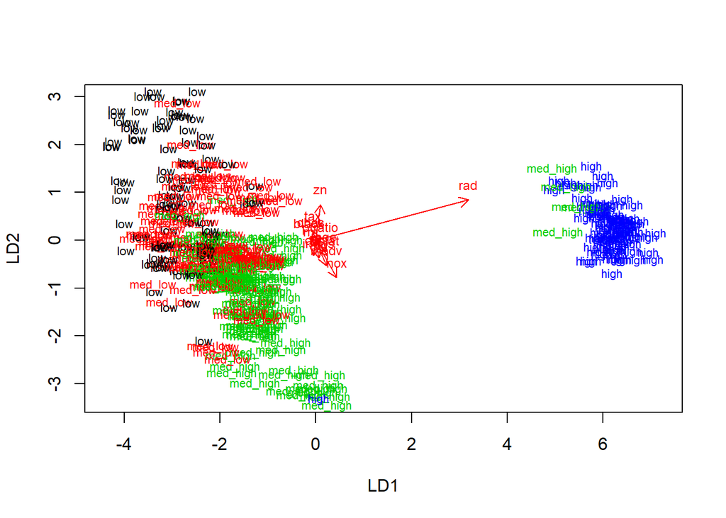

```r
# The function for lda biplot arrows
lda.arrows <- function(x, myscale = 1, arrow_heads = 0.1, color = "red", tex = 0.75, choices = c(1,2)){
  heads <- coef(x)
  arrows(x0 = 0, y0 = 0,
         x1 = myscale * heads[,choices[1]],
         y1 = myscale * heads[,choices[2]], col=color, length = arrow_heads)
  text(myscale * heads[,choices], labels = row.names(heads),
       cex = tex, col=color, pos=3)
}

# Target classes as numeric
classes <- as.numeric(train$crime)

# Plot the lda results
plot(lda.fit, dimen = 2, col = classes, pch = classes)
lda.arrows(lda.fit, myscale = 1)
```

# Predicting with the model

We split our data earlier so that we have the test set and the correct class labels. Let’s have a look on how the LDA model performs when predicting on new (test) data.

```r
# Predict classes with test data
lda.pred <- predict(lda.fit, newdata = test)
# Cross tabulate the results
table(correct = correct_classes, predicted = lda.pred$class)
```

```
##           predicted
## correct    low med_low med_high high
##   low       14      12        3    0
##   med_low    2      13        2    0
##   med_high   0      13       11    1
##   high       0       0        0   31
```

# Clustering

Similarity or dissimilarity of objects can be measured with distance measures. There are many different measures for different types of data. The most common or “normal” distance measure is Euclidean distance, which I will use in the following exercise.

```r
boston_scaled <- as.data.frame(scale(Boston))
# euclidean distance matrix
dist_eu <- dist(boston_scaled)
# look at the summary of the distances
summary(dist_eu)
```

```
##    Min. 1st Qu.  Median    Mean 3rd Qu.    Max.
##  0.1343  3.4625  4.8241  4.9111  6.1863 14.3970
```

Next step is to cluster the data with k-means. In our LDA model, there are four classes, which could be a good choice to start.

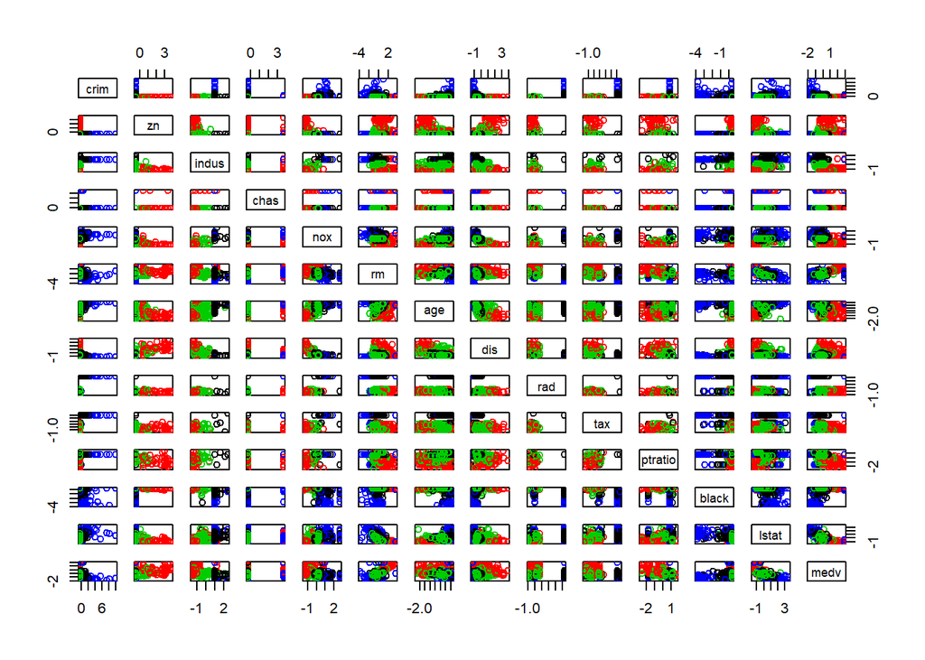

```r
# k-means clustering
km <-kmeans(dist_eu, centers = 4)
# Plot the Boston dataset with clusters
pairs(boston_scaled, col = km$cluster)
```

K-means needs the number of clusters as an argument. There are many ways to look at the optimal number of clusters and a good way might depend on the data you have.

One way to determine the number of clusters is to look at how the total of within cluster sum of squares (WCSS) behaves when the number of cluster changes. When you plot the number of clusters and the total WCSS, the optimal number of clusters is when the total WCSS drops radically.

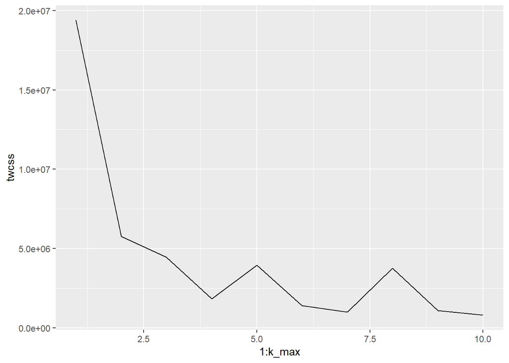

```r
# determine the number of clusters
k_max <- 10
# Calculate the total within sum of squares using the function.
twcss <- sapply(1:k_max, function(k){kmeans(Boston, k)$tot.withinss})

# Visualize the results.
qplot(x = 1:k_max, y = twcss, geom = 'line')
```

The optimal number of cluster is where the TWCSS drops radically. The graphics above showcases that the change happens with two clusters. Let’s cluster the data with two clusters:

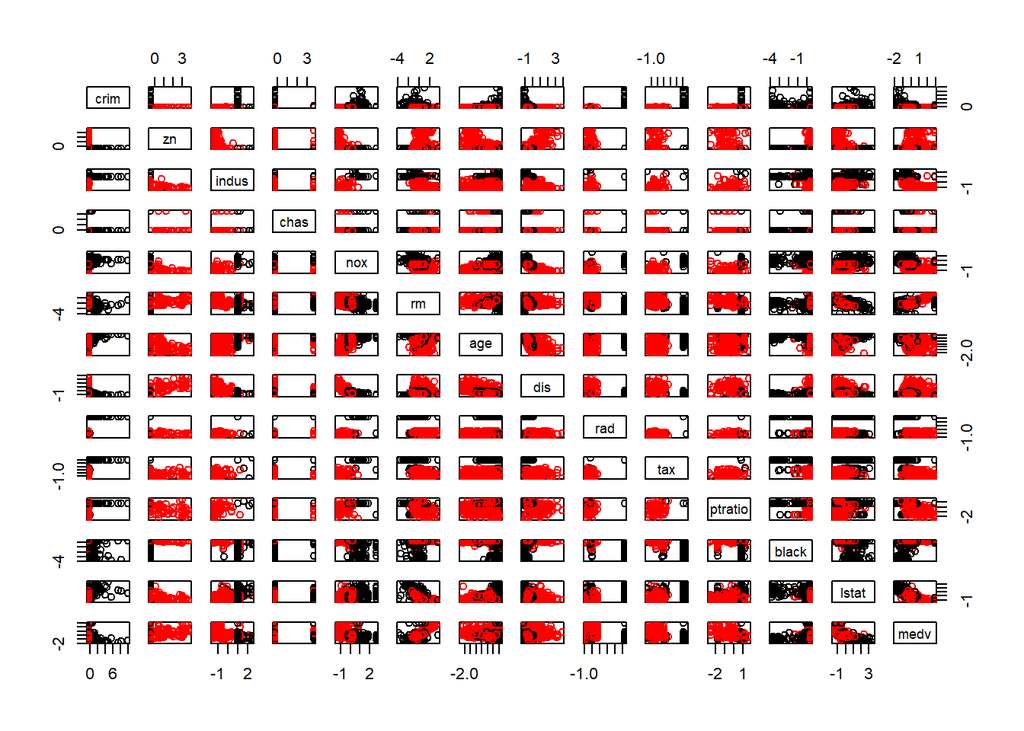

```r
# k-means clustering
km <-kmeans(dist_eu, centers = 2)
# Plot the clusters
pairs(boston_scaled, col = km$cluster)
```

When using euclidian distance, the optimal number of clusters seems to be two.

# Bonus: Perform k-means on the original Boston data with some reasonable number of clusters (> 2)

The Boston data is reloaded and rescaled.

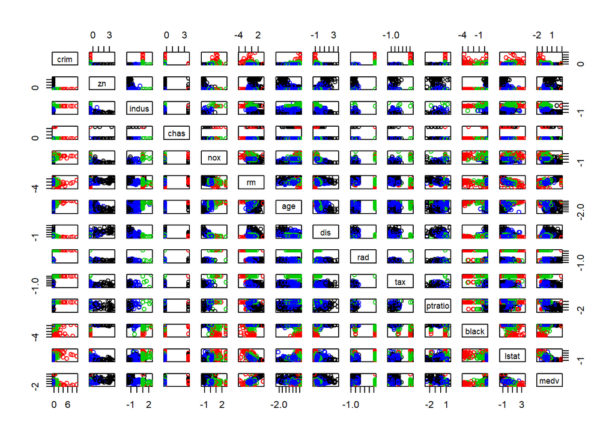

LDA is performed using the clusters as target classes. All the variables in the Boston data are included in the LDA model. The results are visualized with a biplot (arrows are included representing the relationships of the original variables to the LDA solution).

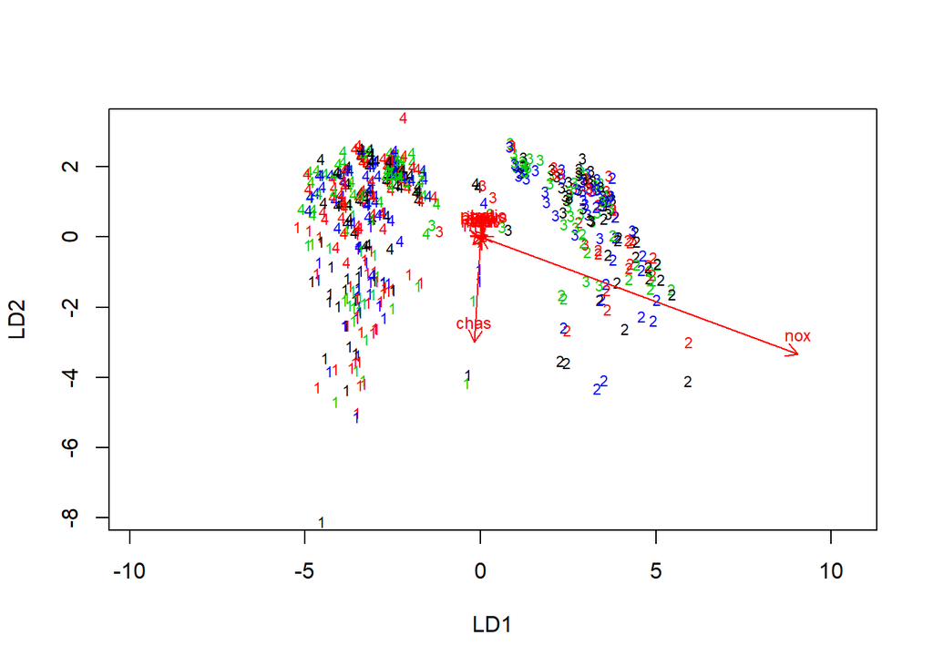

```r
#Perform LDA using the clusters as target classes. Visualize the results with a biplot
lda.fit_2 <- lda(km$cluster ~., data = Boston)
lda.arrows <- function(x, myscale = 1, arrow_heads = 0.1, color = "red", tex = 0.75, choices = c(1,2)){
  heads <- coef(x)
  arrows(x0 = 0, y0 = 0,
         x1 = myscale * heads[,choices[1]],
         y1 = myscale * heads[,choices[2]], col=color, length = arrow_heads)
  text(myscale * heads[,choices], labels = row.names(heads),
       cex = tex, col=color, pos=3)
}
plot(lda.fit_2, dimen = 2, col= classes, pch=classes)
lda.arrows(lda.fit_2, myscale = 1)
```

The graphics above visualize LDA model with the K-means clusters as the target variable. The most influential linear separator is variable nitrogen oxides concentration (nox). The second longiest arrow is variable Charles River dummy variable (chas). For other variables, let’s have a look at the vectors more closely.

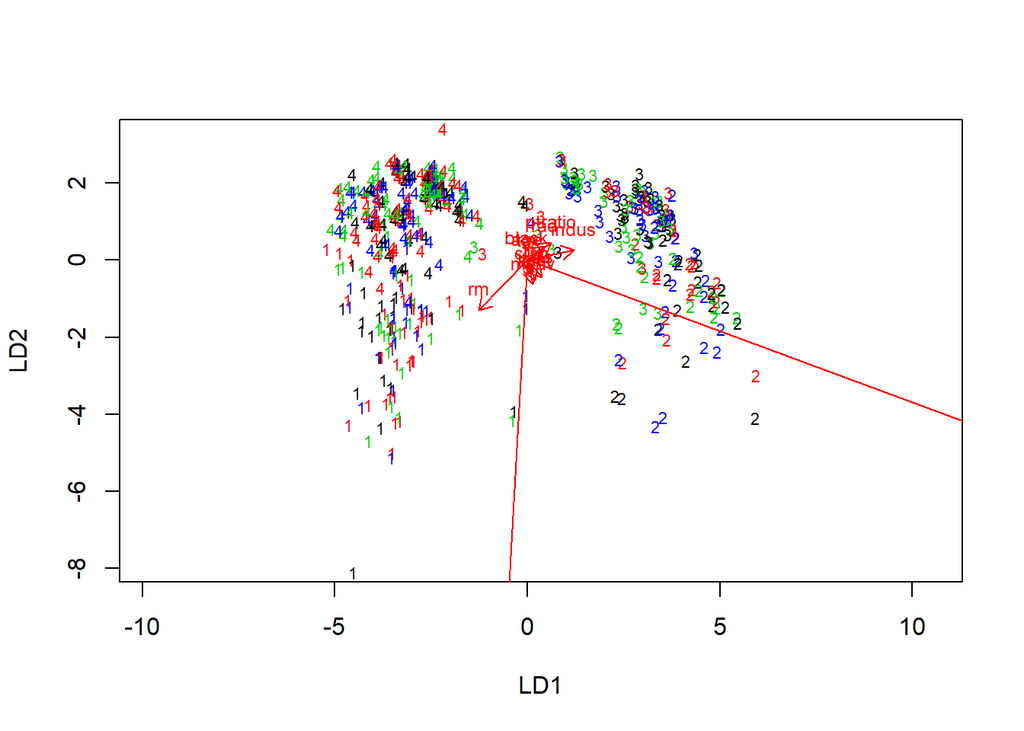

The graphics above showcases that the variables average number of rooms per dwelling (rm) and pupil-teacher ratio by town (ptratio) seem to be linear separators that separate the clusters.